# Cross Sectional data descriptive

Catherine Rolls

2026-01-28

Load dataset: This has already had exclusions applied to it, it is a complete case dataset

Data set of complete case participants for analysis

# Demographics of dataset following exclusions

##### *Age*

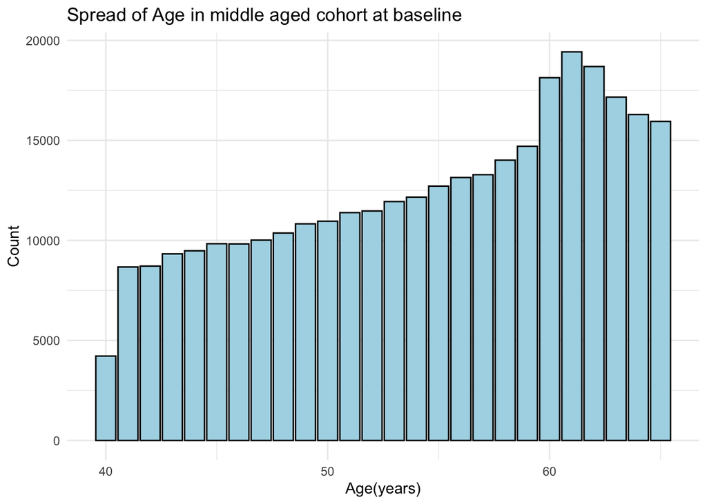

##### *Sex*

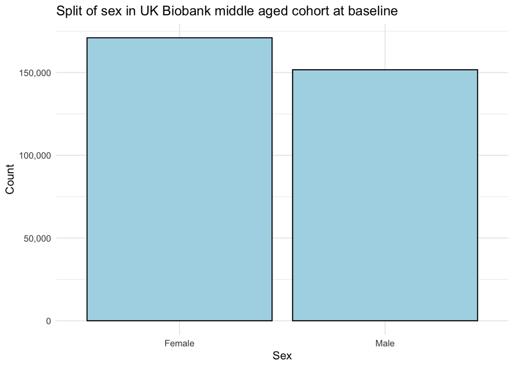

##### *Ethnicity*

Ethnicity has multiple catagoies in UK Biobank, these have been recoded to groupings that are most relevant to bone health.

Ethnicity was recoded to show the following groupings - 1 = White, - 2 = Asian and British Asian, - 3 = Black and Black British, - 4 = Mixed

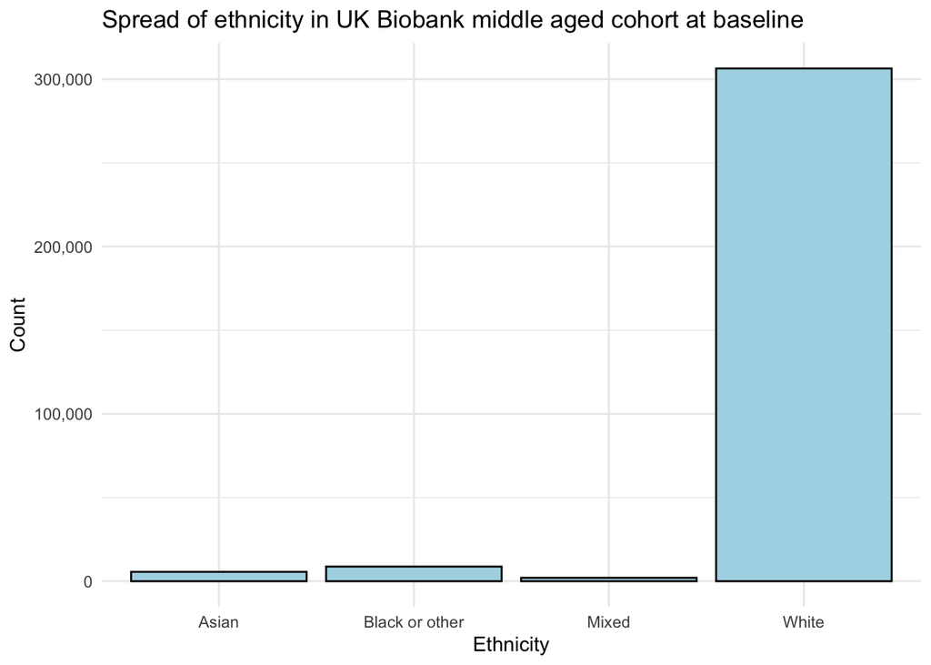

### Exposure variables (PA)

Participants were asked about activities undertaken in the last 4 weeks including frequency, intensity and duration. These are reported as raw values. From these a number of derived Metabolic Equivalent Task (MET) minutes of activity were also derived.

We have added a derived value of mins/wk spent in each activity for use in comparing to the accelerometry data later.

Activity measures (split into moderate, vigorous, walking and summed activity)

- number of days of activity per week
- duration of activity per week
- mins/wk of activity
- MET mins of activity per week

#### Missing data

We are using only participants with all of duration and number of days/wk of activity in our main analysis. Those with missing values in either column are considered NA in the MET calculations and mins/wk calculations. This differs to the UKB anaysis where some data is imputed if just duration is missing. We will use this for comparison in the sensitivity analysis.

#### Unable to walk

- For those who respond that they were unable to walk instead of removing them they are given a value of 0 under time spent walking.

#### Derivation and cutpoints

The full IPAQ calculates total physical activity as a combination of both leisure time PA (LTPA) as well as domains of work and normal activity - as such the resulting median MET-minutes is higher than for participation in LTPA alone. The general public health recommendations of 30 mins of MVPA are relatively low with most adults being able to achieve this regardless of leisure time activity. To look at the health benefits of LTPA higher cut point thresholds are needed for UKB IPAQ data.

#### Moderate activity

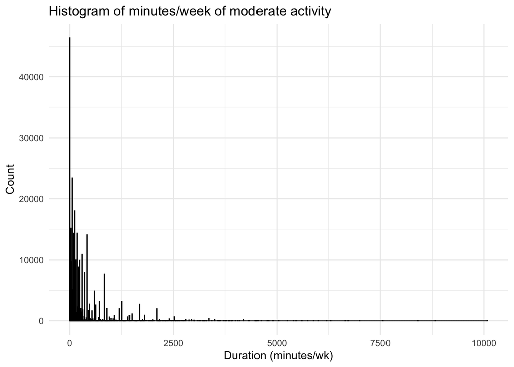

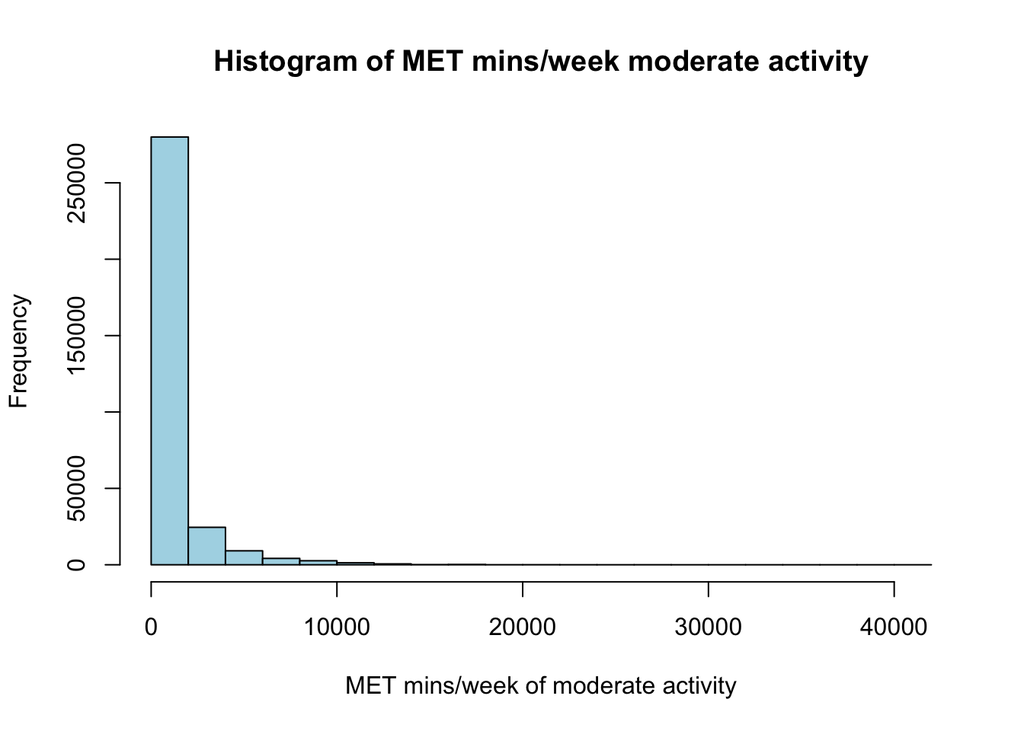

```
## Saved: ../results/tables/Table_3.1.docx
```

| sex | Variable | N | Mean | SD | Median | Min | Max | IQR_low | IQR_high |
| --- | --- | --- | --- | --- | --- | --- | --- | --- | --- |
| Female | mins_wk_mod | 171,043 | 248.06 | 404.29 | 120 | 0 | 8,820 | 30 | 300 |
| Female | MET_mod | 171,043 | 992.22 | 1,617.15 | 480 | 0 | 35,280 | 120 | 1,200 |
| Male | mins_wk_mod | 151,710 | 281.74 | 493.26 | 105 | 0 | 10,080 | 30 | 300 |
| Male | MET_mod | 151,710 | 1,126.95 | 1,973.04 | 420 | 0 | 40,320 | 120 | 1,200 |
| Total | mins_wk_mod | 322,753 | 263.89 | 448.63 | 120 | 0 | 10,080 | 30 | 300 |
| Total | MET_mod | 322,753 | 1,055.55 | 1,794.51 | 480 | 0 | 40,320 | 120 | 1,200 |

#### Vigorous activity

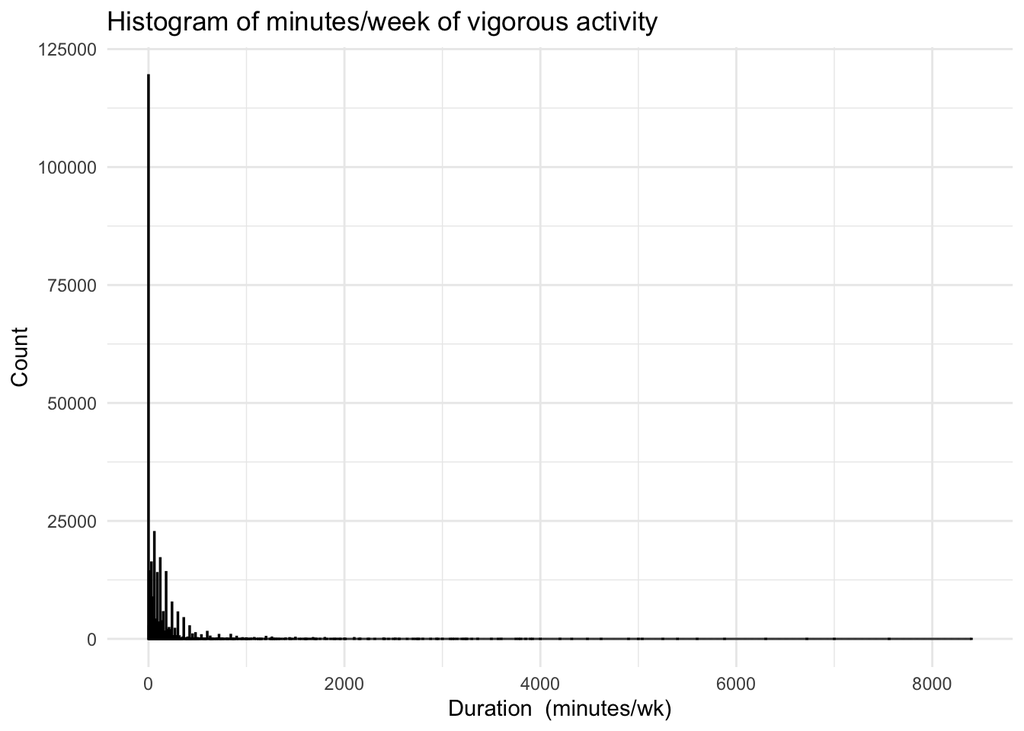

[figure not shown]

```
## Saved: ../results/tables/Table_3.2.docx
```

| sex | Variable | N | Mean | SD | Median | Min | Max | IQR_low | IQR_high |
| --- | --- | --- | --- | --- | --- | --- | --- | --- | --- |
| Female | mins_wk_vig | 171,043 | 75.97 | 149.25 | 24 | 0 | 8,400 | 0 | 90 |
| Female | MET_vig | 171,043 | 607.75 | 1,194.03 | 192 | 0 | 67,200 | 0 | 720 |
| Male | mins_wk_vig | 151,710 | 112.74 | 240.98 | 40 | 0 | 7,560 | 0 | 125 |
| Male | MET_vig | 151,710 | 901.91 | 1,927.85 | 320 | 0 | 60,480 | 0 | 1,000 |
| Total | mins_wk_vig | 322,753 | 93.25 | 198.59 | 30 | 0 | 8,400 | 0 | 120 |
| Total | MET_vig | 322,753 | 746.02 | 1,588.74 | 240 | 0 | 67,200 | 0 | 960 |

#### Walking behaviour

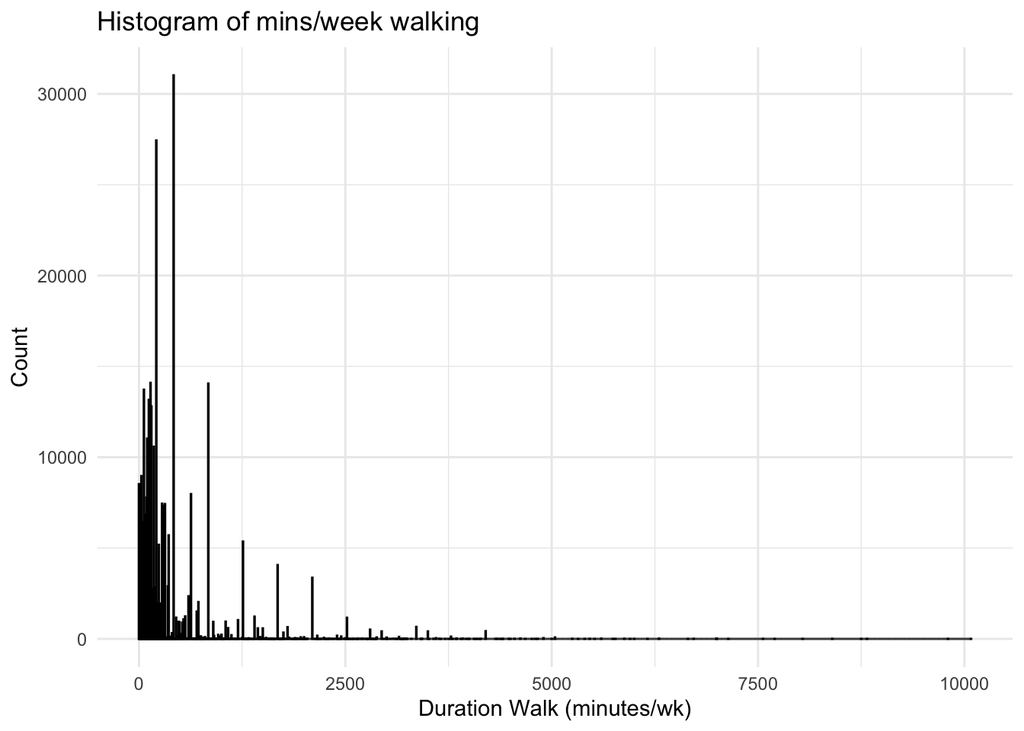

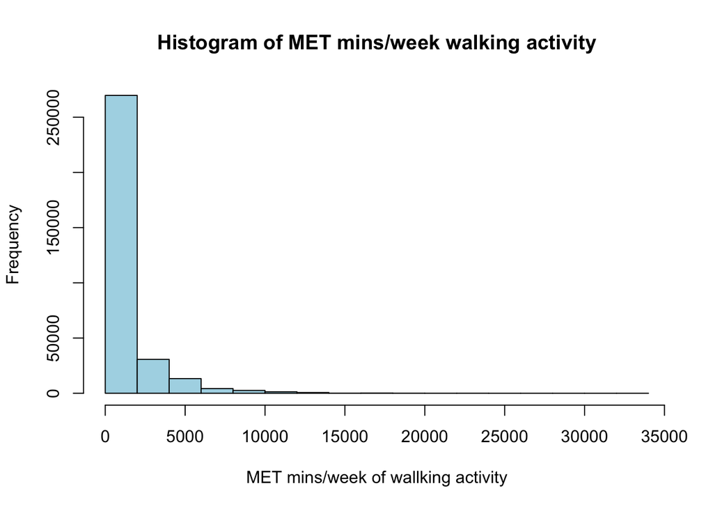

```
## Saved: ../results/tables/Table_3.3.docx
```

| sex | Variable | N | Mean | SD | Median | Min | Max | IQR_low | IQR_high |
| --- | --- | --- | --- | --- | --- | --- | --- | --- | --- |
| Female | mins_wk_walk | 171,043 | 359.38 | 505.59 | 210 | 0 | 10,080 | 100 | 420 |
| Female | MET_walk | 171,043 | 1,185.94 | 1,668.45 | 693 | 0 | 33,264 | 330 | 1,386 |
| Male | mins_wk_walk | 151,710 | 381.53 | 567.80 | 210 | 0 | 8,750 | 90 | 420 |
| Male | MET_walk | 151,710 | 1,259.05 | 1,873.73 | 693 | 0 | 28,875 | 297 | 1,386 |
| Total | mins_wk_walk | 322,753 | 369.79 | 535.84 | 210 | 0 | 10,080 | 90 | 420 |
| Total | MET_walk | 322,753 | 1,220.31 | 1,768.29 | 693 | 0 | 33,264 | 297 | 1,386 |

#### Combined activity

- MVPA This variable has been derived along with mins/wk in MVPA in order to compare to other published data and the accelerometry data

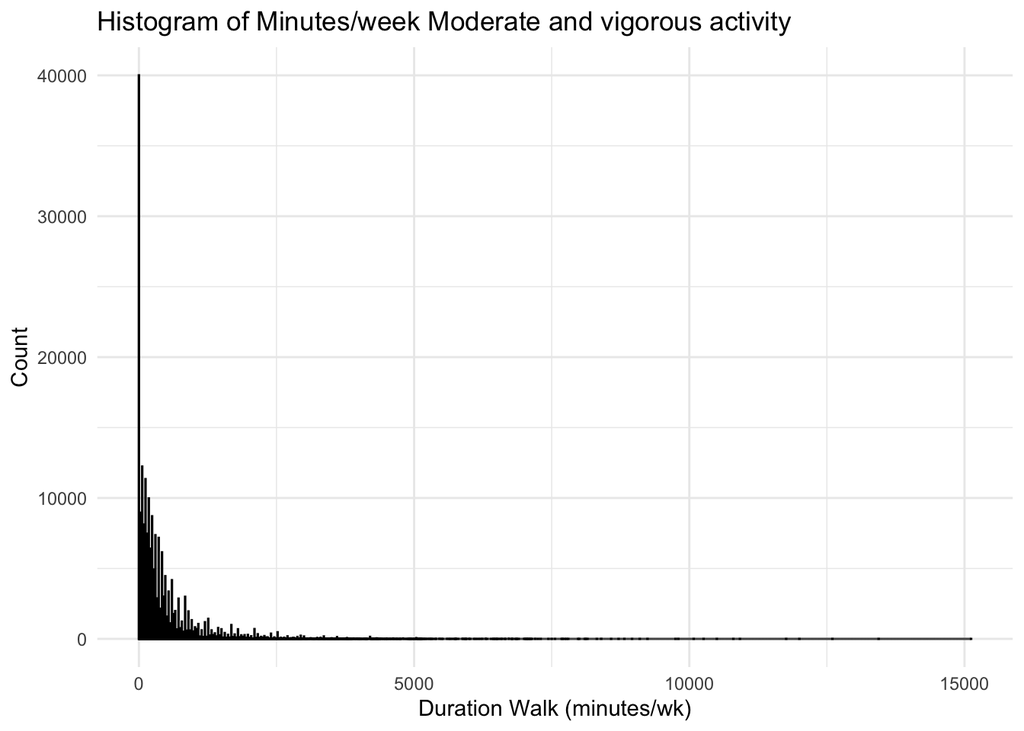

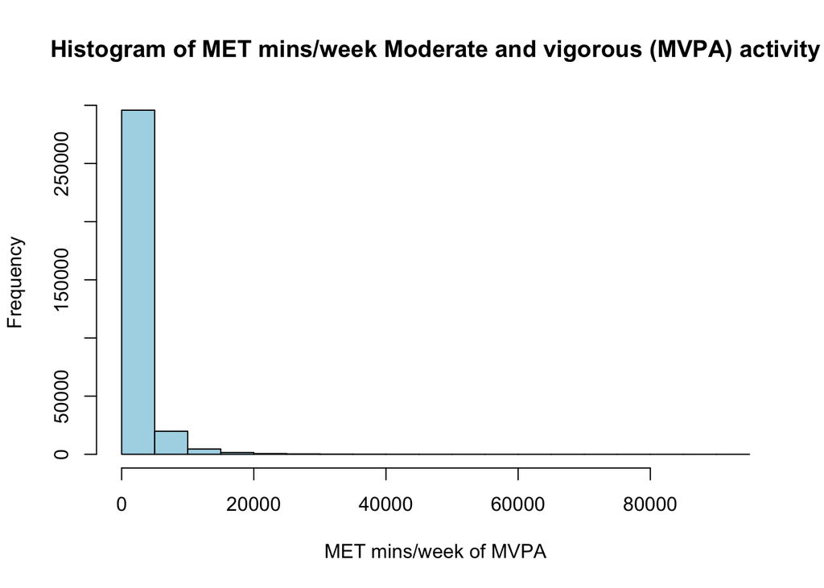

```
## Saved: ../results/tables/Table_3.4.docx
```

| sex | Variable | N | Mean | SD | Median | Min | Max | IQR_low | IQR_high |
| --- | --- | --- | --- | --- | --- | --- | --- | --- | --- |
| Female | mins_wk_MVPA | 171,043 | 324.02 | 481.23 | 175 | 0 | 10,920 | 60 | 400 |
| Female | MET_MVPA | 171,043 | 1,599.97 | 2,346.96 | 840 | 0 | 77,280 | 240 | 2,000 |
| Male | mins_wk_MVPA | 151,710 | 394.47 | 643.13 | 180 | 0 | 15,120 | 50 | 440 |
| Male | MET_MVPA | 151,710 | 2,028.85 | 3,346.82 | 960 | 0 | 90,720 | 240 | 2,400 |
| Total | mins_wk_MVPA | 322,753 | 357.14 | 564.25 | 180 | 0 | 15,120 | 55 | 420 |
| Total | MET_MVPA | 322,753 | 1,801.57 | 2,868.80 | 920 | 0 | 90,720 | 240 | 2,160 |

#### Summed days activity per week

Sum of days performing walking, moderate and vigorous activity - question derived from answers to number of days doing each of the following in a week so total of all will add up to more than 7 but cant be over 21.

- Summed MET minutes per week for all activity

```
## Saved: ../results/tables/Table_3.3.docx
```

| sex | Variable | N | Mean | SD | Median | Min | Max | IQR_low | IQR_high |
| --- | --- | --- | --- | --- | --- | --- | --- | --- | --- |
| Female | summed_MET_all | 171,043 | 2,785.92 | 3,398.64 | 1,734 | 0 | 80,052 | 812 | 3,408 |
| Male | summed_MET_all | 151,710 | 3,287.90 | 4,585.45 | 1,824 | 0 | 115,668 | 813 | 3,786 |
| Total | summed_MET_all | 322,753 | 3,021.88 | 4,008.42 | 1,773 | 0 | 115,668 | 813 | 3,573 |

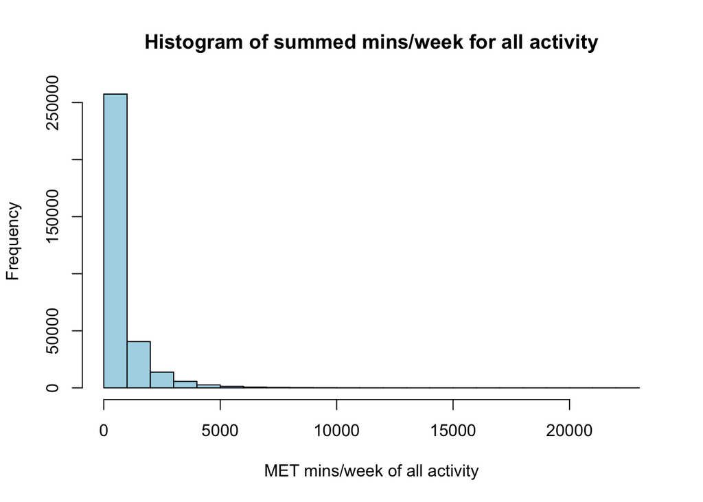

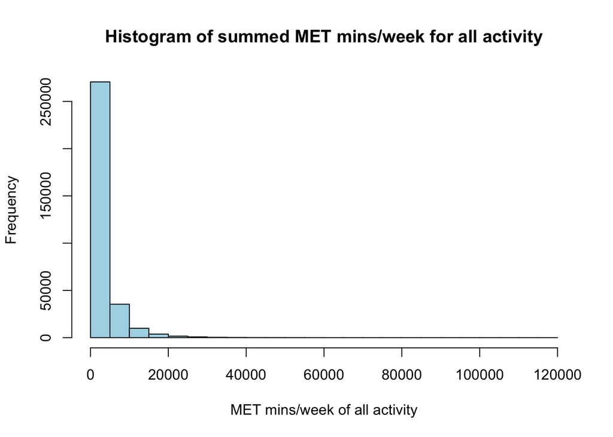

#### International Physical Activity Questionnaire (IPAQ)

Based on activity frequency, duration and intensity an activity group is derived as being low, moderate or high active.

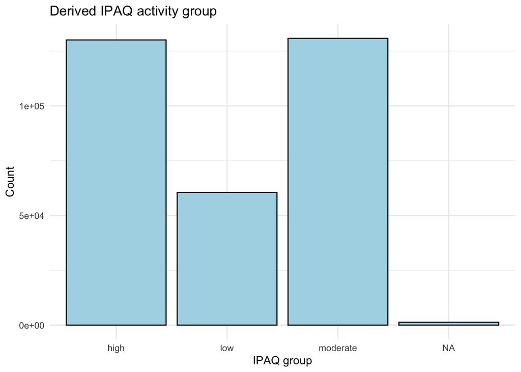

### Physical activity status by outcome

```
## Saved: ../results/tables/Table_3.5.docx
```

| Fracture status | Variable | N | Mean | SD | Median | Min | Max | IQR_low | IQR_high |
| --- | --- | --- | --- | --- | --- | --- | --- | --- | --- |
| No | MET_mod | 292,665 | 1,040.97 | 1,776.11 | 420 | 0 | 40,320 | 120 | 1,200 |
| No | MET_vig | 292,665 | 732.44 | 1,565.01 | 240 | 0 | 67,200 | 0 | 960 |
| No | MET_MVPA | 292,665 | 1,773.41 | 2,830.07 | 900 | 0 | 80,640 | 240 | 2,160 |
| No | MET_walk | 292,665 | 1,209.39 | 1,751.58 | 693 | 0 | 33,264 | 297 | 1,386 |
| No |  |  |  |  |  |  |  |  |  |
| Yes | MET_mod | 30,088 | 1,197.37 | 1,958.92 | 480 | 0 | 30,240 | 160 | 1,440 |
| Yes | MET_vig | 30,088 | 878.11 | 1,798.05 | 320 | 0 | 60,480 | 0 | 1,080 |
| Yes | MET_MVPA | 30,088 | 2,075.48 | 3,208.53 | 1,080 | 0 | 90,720 | 280 | 2,520 |
| Yes | MET_walk | 30,088 | 1,326.53 | 1,919.99 | 693 | 0 | 28,875 | 330 | 1,386 |
| Yes |  |  |  |  |  |  |  |  |  |
|  | MET_mod | 322,753 | 1,055.55 | 1,794.51 | 480 | 0 | 40,320 | 120 | 1,200 |
|  | MET_vig | 322,753 | 746.02 | 1,588.74 | 240 | 0 | 67,200 | 0 | 960 |
|  | MET_MVPA | 322,753 | 1,801.57 | 2,868.80 | 920 | 0 | 90,720 | 240 | 2,160 |
|  | MET_walk | 322,753 | 1,220.31 | 1,768.29 | 693 | 0 | 33,264 | 297 | 1,386 |

### Visual comparison (box plots)

#### Moderate PA

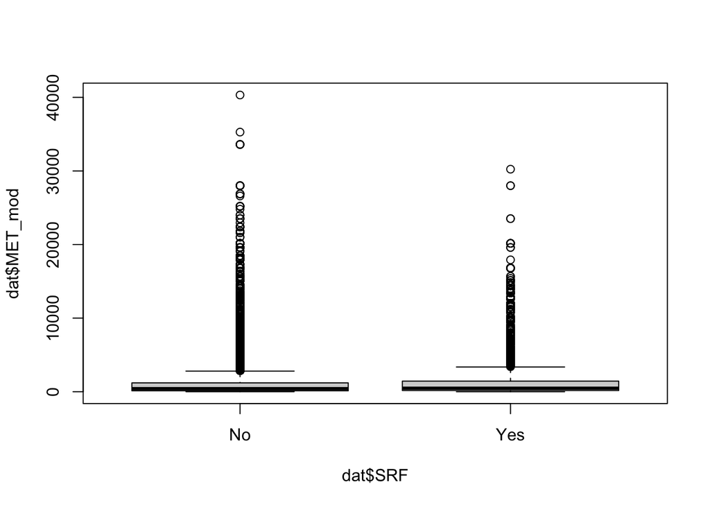

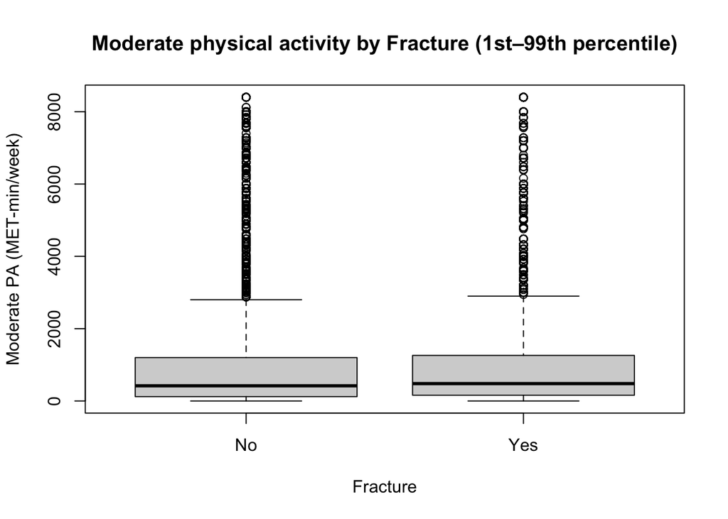

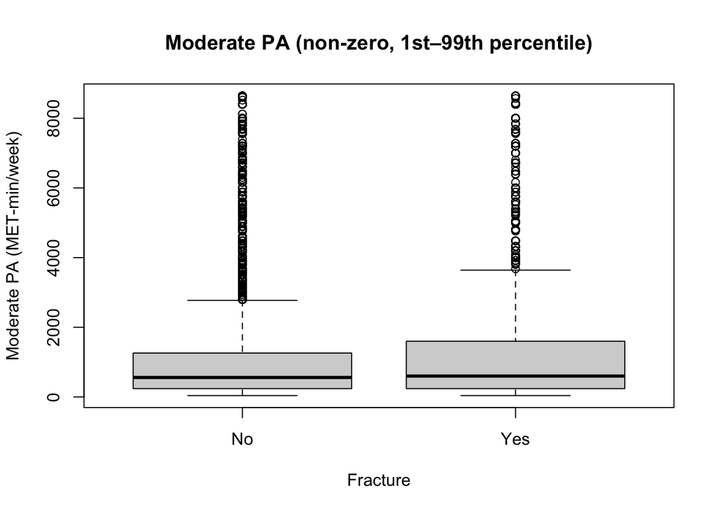

#### Vigorous PA

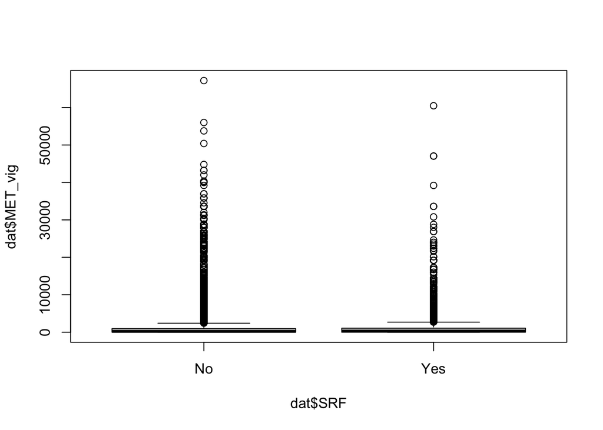

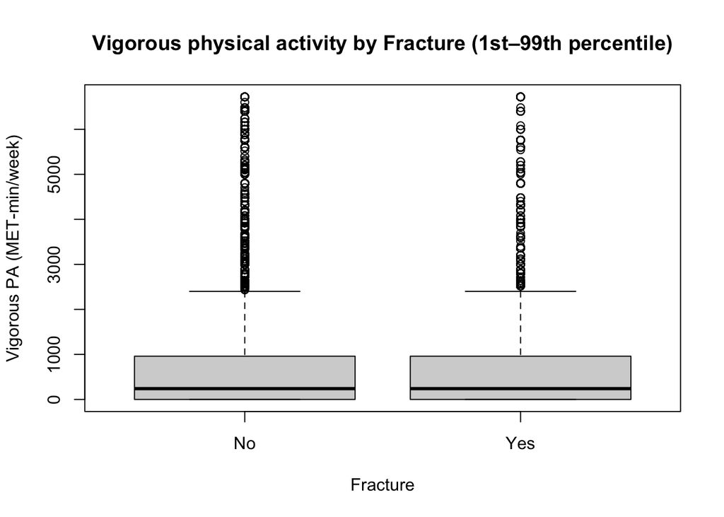

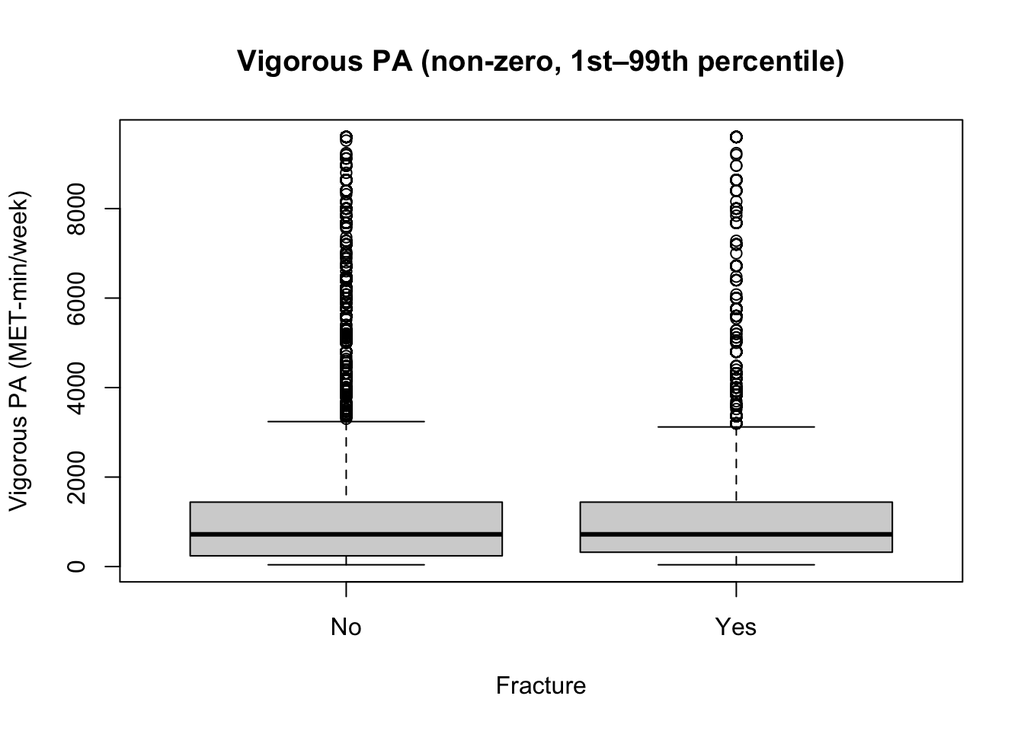

#### MVPA

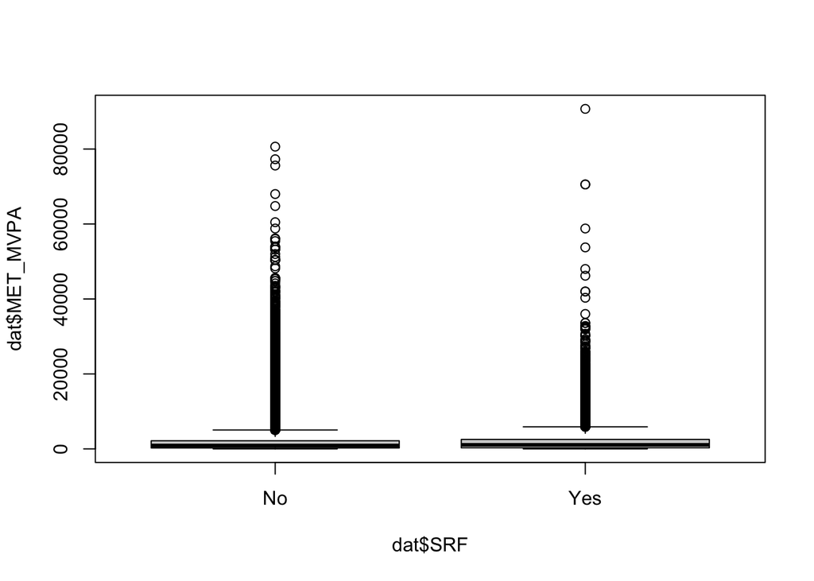

[figure not shown]

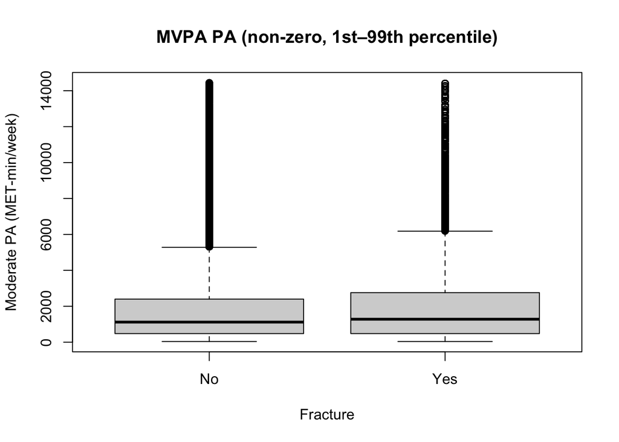

### Relationship between moderate and vigorous PA

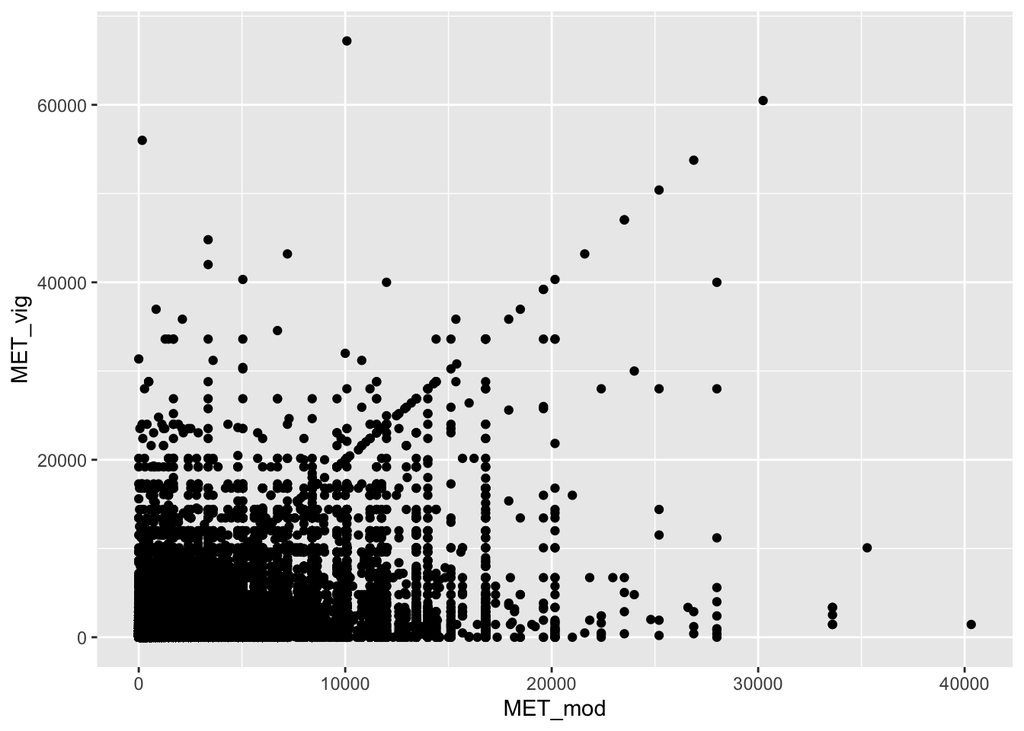

### Log transformations if needed

All data is skewed, look at whether log transformation helps normalise the data

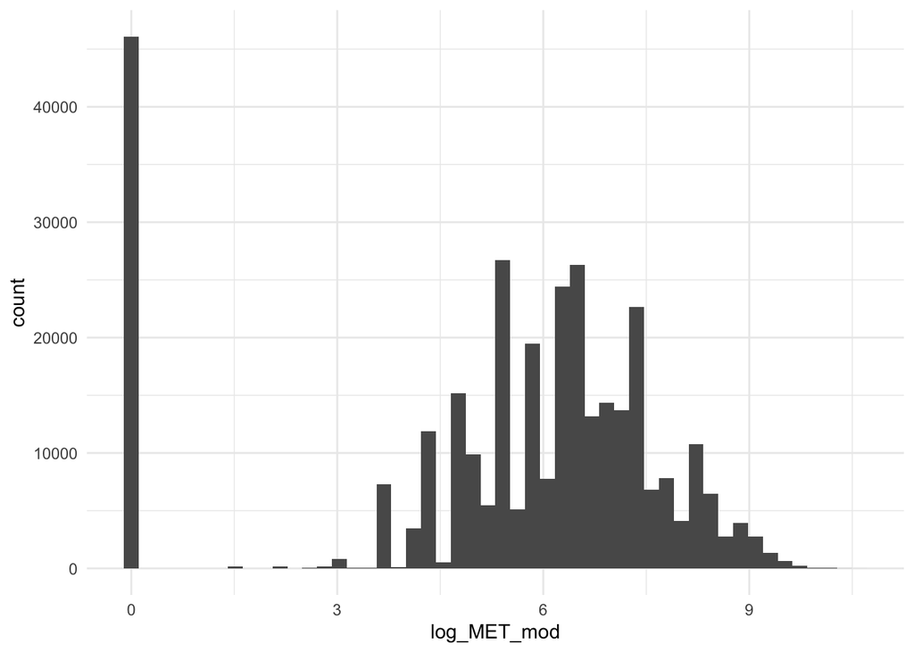

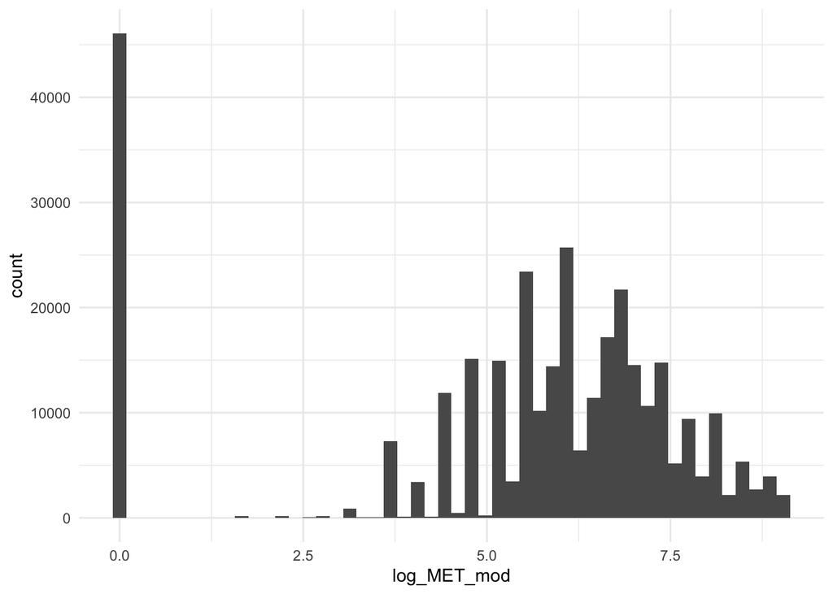

# Log transformed MET_vig and MET_walk

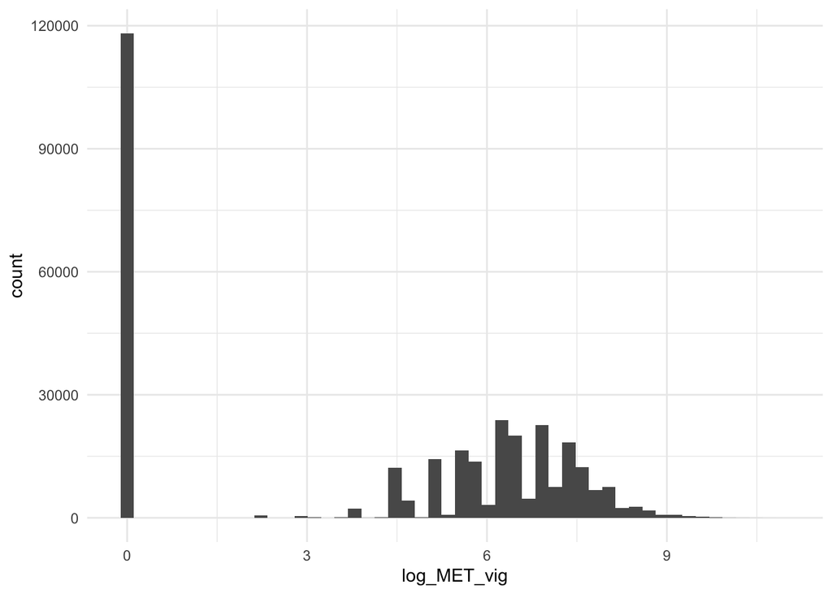

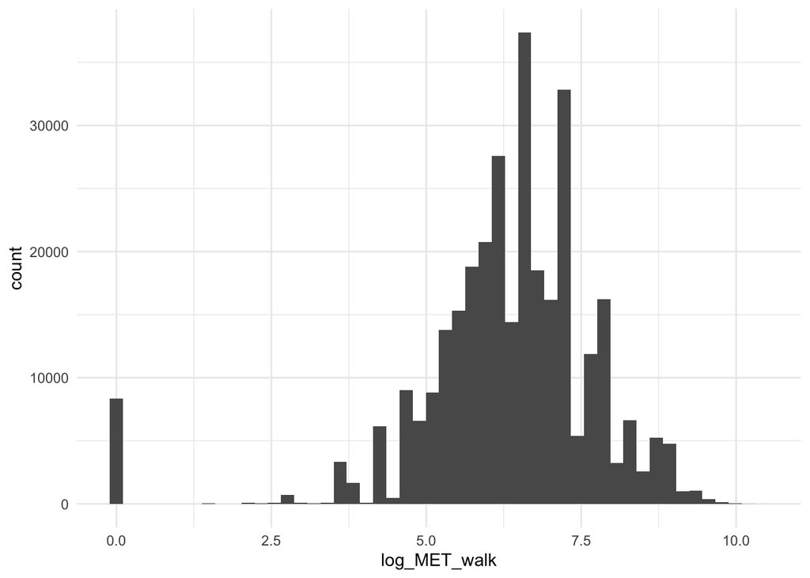